# UK Cars Seasonal Tends in Production 1997-2005

#### Effects of Outliers on Seasonally Adjusted Time Series

Figures 8 - 11 show the effects of an outlier in different parts of the distribution. * Outliers make the seasonal adjustment less effective, the resulting distributions had more peaked hills and valleys. *The distribution seemed most effected by the outlier at the beginning. It effected the rest of the distribution, especially at the high end.*  
The middle outlier had effected the lower end but to lesser a degree then the lower outlier *The high outlier changed the distribution the lease.

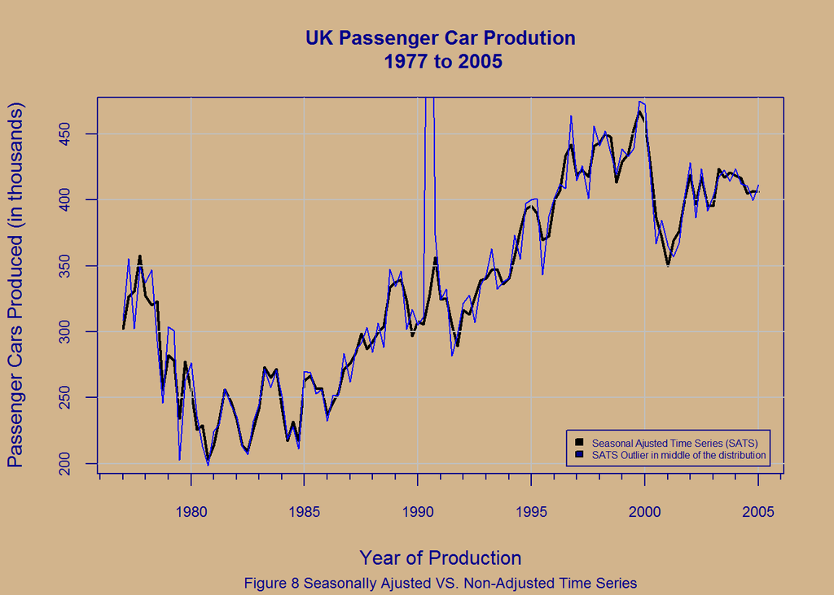

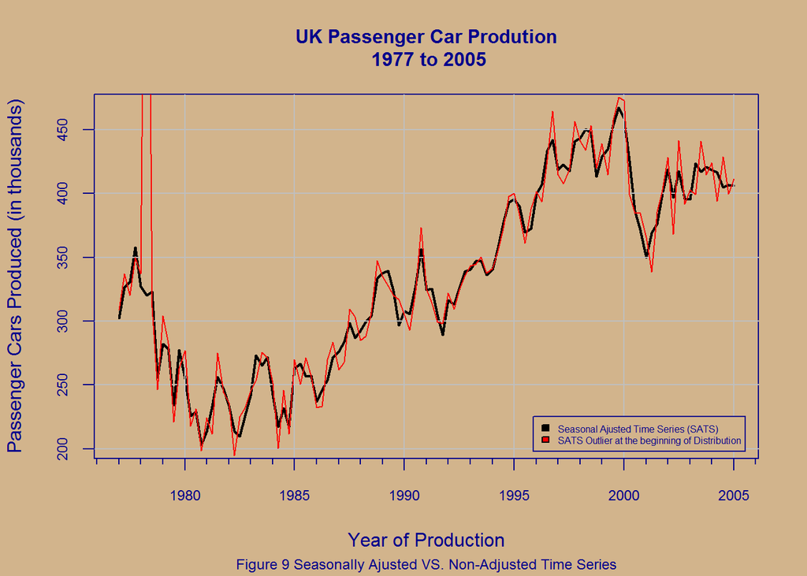

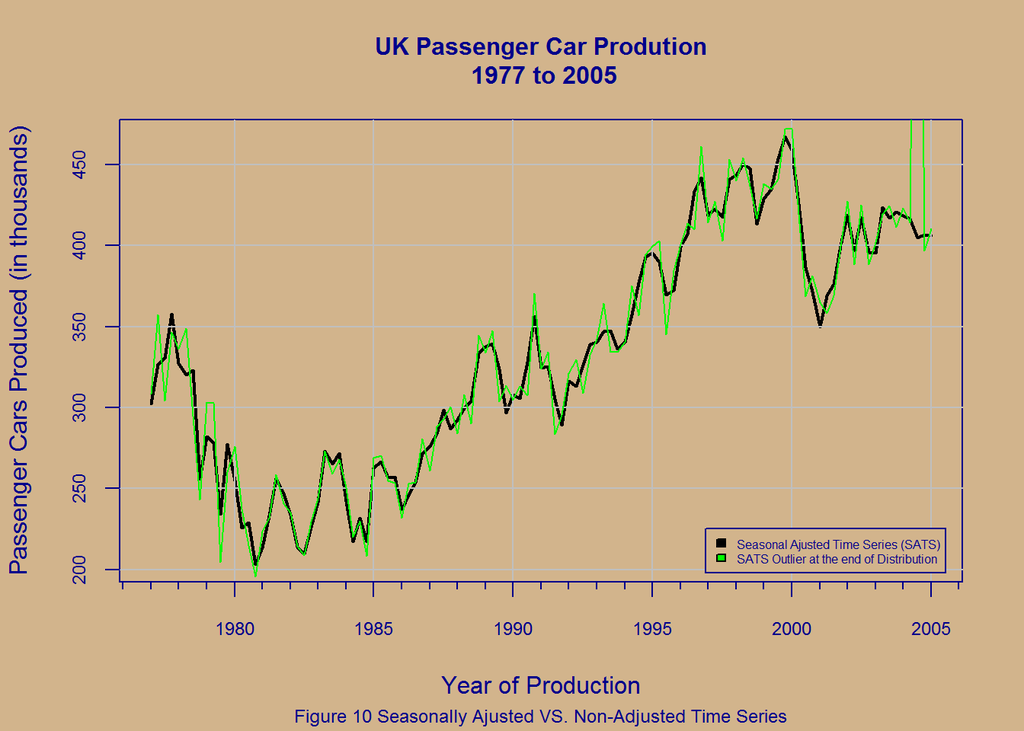

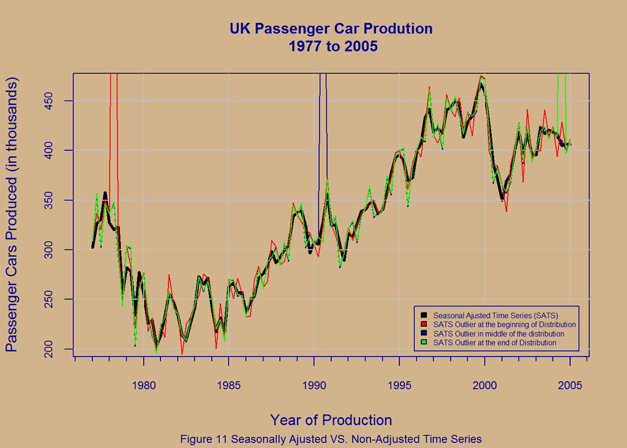

## Conclusions

There was a long term upward trend between 1985 and 1999, producing 185 more cars in 1999 then in 1985, 446 and 261 respectively. The upward trend reversed in 2000 with a short term downward trend through 2001, production 374, with the production falling to pre 1995 levels of 382 cars but rebounding through the end of 2004 ending at 412 cars.

There was a seasonal effect shown by the decrease in productivity during the summat months, year over year. This might be explained by the custom to take vacation during the summer months.

## References

1. Seasonality Definition Investopediahttp://www.investopedia.com/terms/s/seasonality.asp#ixzz4R5xGo37j

2.Trend Definition Investopedia http://www.investopedia.com/terms/t/trend.asp#ixzz4R5yAYr5z